# Kalibrowany estymator IPW

```r
library(nonprobsvy) ## wersja 0.2.3
library(cobalt)
library(WeightIt)
```

```r
data(admin) ## próba nielosowa (S_A)
head(admin)
```

```
   id private size nace region single_shift
1 j_1       0    L    P     30        FALSE
2 j_2       0    L    O     14         TRUE
3 j_3       0    L    O     04         TRUE
4 j_4       0    L    O     24         TRUE
5 j_5       0    L    O     04         TRUE
6 j_6       1    L    C     28        FALSE
```

```r
data(jvs) ## próba losowa (S_B)
head(jvs)
```

```
   id private size nace region weight
1 j_1       0    L    O     14      1
2 j_2       0    L    O     24      6
3 j_3       0    L  R.S     14      1
4 j_4       0    L  R.S     14      1
5 j_5       0    L  R.S     22      1
6 j_6       0    M  R.S     26      1
```

```r
jvs_svy <- svydesign(ids = ~ 1,
                     weights = ~ weight,
                     strata = ~ size + nace + region,
                     data = jvs)
```

- 1 źródło: próba nielosowa S_A (dane z CBOP)
- 2 źródło: próba losowa S_B (dane z badania popyt na pracę)

Ostatnim razem wykorzystywaliśmy pseudo-funkcję największej wiarygodności (daną poniżej) do estymcji parametrów $\boldsymbol{\gamma}$.

$$\ell^*(\boldsymbol{\gamma}) = \sum_{i \in S_{A}} \log \left\{\frac{\pi\left(\boldsymbol{x}_i, \boldsymbol{\gamma}\right)}{1-\pi\left(\boldsymbol{x}_i, \boldsymbol{\gamma}\right)}\right\} + \sum_{i \in S_{B}} d_i^B \log \left\{1-\pi\left(\boldsymbol{x}_i, \boldsymbol{\gamma}\right)\right\}.$$

Ta metoda jest przydatna gdy 1) mamy dostęp do danych z populacji lub 2) mamy dostęp do danych jednostkowych z badania reprezentacyjnego.

Ogarniczenia są jednak następujące:

- nie zawsze mamy dostęp do danych jednostkowych – dysponujemy wyłącznie wartościami globalnymi tj. wiemy ile jest kobiet czy mężczyzn
- wagi uzyskane z metody MLE nie gwarantują odtworzenia znanych lub estymowanych wartości globalnych tj. nie sumują się do liczby kobiet i mężczyzn.

W takim przypadku możemy zastosować podejście oparte o rozwiązywanie uogólnionych równań estymujących (ang. *generalized estimating equations*).

- Niech $\boldsymbol{h}(\boldsymbol{x}, \boldsymbol{\gamma})$ będzie wektorem funkcji o tym samym wymiarze co $\boldsymbol{\gamma}$
- Definiujemy funkcję $\boldsymbol{G}(\boldsymbol{\gamma})$ jako:
  $$\boldsymbol{G}(\boldsymbol{\gamma})=\sum_{i \in S_A} \boldsymbol{h}\left(\boldsymbol{x}_i, \boldsymbol{\gamma}\right)-\sum_{i \in S_B} d_i^B \pi\left(\boldsymbol{x}_i, \boldsymbol{\gamma}\right) \boldsymbol{h}\left(\boldsymbol{x}_i, \boldsymbol{\gamma}\right)$$
- Rozwiązanie równania $\boldsymbol{G}(\boldsymbol{\gamma})=\boldsymbol{0}$ daje zgodny estymator $\hat{\boldsymbol{\gamma}}$
- Najczęściej wybierane funkcje to $\boldsymbol{h}\left(\boldsymbol{x}_i, \boldsymbol{\gamma}\right) = \boldsymbol{x}_i$ i $\boldsymbol{h}\left(\boldsymbol{x}_i, \boldsymbol{\gamma}\right) = \boldsymbol{x}_i \pi\left(\boldsymbol{x}_i, \boldsymbol{\gamma}\right)^{-1}$
- Dla drugiego wariantu funkcji $\boldsymbol{h}$ otrzymujemy IPW:
  $$\boldsymbol{G}(\boldsymbol{\theta}) = \sum_{i \in S_A} \frac{\boldsymbol{x}_i}{\pi\left(\boldsymbol{x}_i, \boldsymbol{\gamma}\right) }-\sum_{i \in S_B} d_i^B \boldsymbol{x}_i$$

To podejście wymaga tylko znajomości sum populacyjnych dla zmiennych pomocniczych $\boldsymbol{x}$ i prowadzi do estymatora podwójnie odpornego przy założeniu, że model zmiennej wynikowej jest liniowy.

Przykład 1:

- estymator IPW: wykorzystujemy jedną zmienną tj.

$$P(R_A = 1 | size)$$
Zaczniemy od standardowego IPW

```r
ipw_mle <- nonprob(selection = ~ size,         ## P(R_1 = 1 | ...)
                    target = ~ single_shift,    ## y - zmienna celu
                    svydesign = jvs_svy,        ## proba losowa S_B
                    data = admin,               ## proba nielosowa S_A
                    method_selection = "logit") ## regresja logistyczna / probit / cloglog

ipw_mle
```

```
A nonprob object
 - estimator type: inverse probability weighting
 - method: logit (mle)
 - auxiliary variables source: survey
 - vars selection: false
 - variance estimator: analytic
 - population size fixed: false
 - naive (uncorrected) estimator: 0.6605
 - selected estimator: 0.6944 (se=0.0382, ci=(0.6196, 0.7693))
```

Porównamy teraz z GEE

```r
ipw_gee <- nonprob(selection = ~ size,         ## P(R_1 = 1 | ...)
                    target = ~ single_shift,    ## y - zmienna celu
                    svydesign = jvs_svy,        ## proba losowa S_B
                    data = admin,               ## proba nielosowa S_A
                    method_selection = "logit", ## regresja logistyczna / probit / cloglog
                    control_selection = control_sel(est_method = "gee"))

ipw_gee
```

```
A nonprob object
 - estimator type: inverse probability weighting
 - method: logit (gee)
 - auxiliary variables source: survey
 - vars selection: false
 - variance estimator: analytic
 - population size fixed: false
 - naive (uncorrected) estimator: 0.6605
 - selected estimator: 0.6944 (se=0.0384, ci=(0.6192, 0.7697))
```

```r
check_balance(~size-1, ipw_mle)
```

```
$nonprob_totals
   sizeL    sizeM    sizeS
 8561.00 13758.00 29550.99

$prob_totals
sizeL sizeM sizeS
 8561 13758 29551

$balance
sizeL sizeM sizeS
 0.00  0.00 -0.01
```

```r
check_balance(~size-1, ipw_gee)
```

```
$nonprob_totals
sizeL sizeM sizeS
 8561 13758 29551

$prob_totals
sizeL sizeM sizeS
 8561 13758 29551

$balance
sizeL sizeM sizeS
    0     0     0
```

```r
coef(ipw_mle)
```

```
$coef_sel
                  [,1]
(Intercept) -0.8619700
sizeM       -0.3850548
sizeS       -1.0725028

$coef_out
NULL
```

```r
coef(ipw_gee)
```

```
$coef_sel
                  [,1]
(Intercept) -0.8619700
sizeM       -0.3850548
sizeS       -1.0725031

$coef_out
NULL
```

Przykład 2:

- estymator IPW: wykorzystujemy wszystie zmienne tj.

$$P(R_A = 1 | size, nace, region, private)$$

Zaczynamy od stadardowego estymatora IPW

```r
ipw_mle2 <- nonprob(selection = ~ size + nace + region + private,         ## P(R_1 = 1 | ...)
                    target = ~ single_shift,    ## y - zmienna celu
                    svydesign = jvs_svy,        ## proba losowa S_B
                    data = admin,               ## proba nielosowa S_A
                    method_selection = "logit") ## regresja logistyczna / probit / cloglog
```

a teraz GEE

```r
ipw_gee2 <- nonprob(selection = ~ size + nace + region + private,         ## P(R_1 = 1 | ...)
                    target = ~ single_shift,    ## y - zmienna celu
                    svydesign = jvs_svy,        ## proba losowa S_B
                    data = admin,               ## proba nielosowa S_A
                    method_selection = "logit", ## regresja logistyczna / probit / cloglog
                    control_selection = control_sel(est_method = "gee"))
```

Porównajmy oszacowania

```r
rbind(
  extract(ipw_mle2),
  extract(ipw_gee2)
)
```

```
        target      mean         SE lower_bound upper_bound
1 single_shift 0.7223628 0.04207711   0.6398932   0.8048324
2 single_shift 0.7041796 0.03980593   0.6261614   0.7821978
```

Porównamy wagi

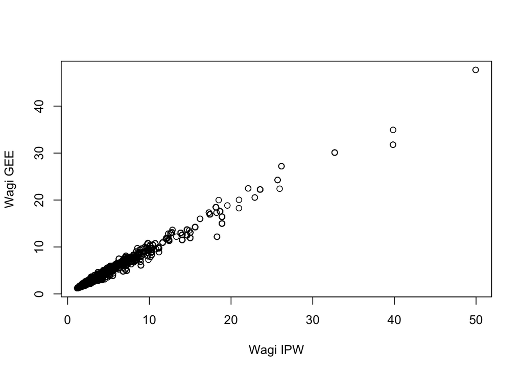

```r
plot(x = weights(ipw_mle2),
     y = weights(ipw_gee2),
     xlab = "Wagi IPW", ylab = "Wagi GEE")
```

```r
summary(weights(ipw_mle2))
```

```
   Min. 1st Qu.  Median    Mean 3rd Qu.    Max.
  1.169   2.673   4.333   5.661   7.178  49.950
```

```r
summary(weights(ipw_gee2))
```

```
   Min. 1st Qu.  Median    Mean 3rd Qu.    Max.
  1.225   2.768   4.382   5.551   7.103  47.712
```

Metoda GEE zapewnia zgodność rozkładów

```r
check_balance(~size-1,ipw_mle2)
```

```
$nonprob_totals
    sizeL     sizeM     sizeS
 8193.376 13529.550 31175.205

$prob_totals
sizeL sizeM sizeS
 8561 13758 29551

$balance
  sizeL   sizeM   sizeS
-367.62 -228.45 1624.21
```

```r
check_balance(~size-1,ipw_gee2)
```

```
$nonprob_totals
sizeL sizeM sizeS
 8561 13758 29551

$prob_totals
sizeL sizeM sizeS
 8561 13758 29551

$balance
sizeL sizeM sizeS
    0     0     0
```

Przykład 3: znamy tylko wartości globalne

- załóżmy, że znamy wartości globalne dla zmiennej size

```r
pop_totals <- c("(Intercept)"=51870, sizeM = 13758, sizeS = 29551)
```

```r
ipw_gee3 <- nonprob(selection = ~ size,         ## P(R_1 = 1 | ...)
                    target = ~ single_shift,    ## y - zmienna celu
                    pop_totals = pop_totals,
                    data = admin,               ## proba nielosowa S_A
                    method_selection = "logit", ## regresja logistyczna / probit / cloglog
                    control_selection = control_sel(est_method = "gee"))

ipw_gee3
```

```
A nonprob object
 - estimator type: inverse probability weighting
 - method: logit (gee)
 - auxiliary variables source: population
 - vars selection: false
 - variance estimator: analytic
 - population size fixed: true
 - naive (uncorrected) estimator: 0.6605
 - selected estimator: 0.6944 (se=0.0138, ci=(0.6675, 0.7214))
 - caution: since `pop_size' is provided, the variance is estimated assuming that `pop_size' is known (not estimated). If this assumption is wrong, specify the appropriate `var_method' in the `control_inf()` function.
```

```r
rbind(
  extract(ipw_gee),
  extract(ipw_gee3)
)
```

```
        target     mean         SE lower_bound upper_bound
1 single_shift 0.694449 0.03841072   0.6191654   0.7697327
2 single_shift 0.694449 0.01375912   0.6674817   0.7214164
```